# R Notebook

# Exercício 8

Esse exercício tem o objetivo de explorar o assunto de séries temporais de forma introdutória. Para isso, existem alguns pacotes que podem nos auxiliar no objetivo desse exercício: capturar séries temporais do mercado financeiro e realizar sua visualização. Abaixo, estão listados três pacotes relacionados ao mercado financeiro que podem ser instalados e carregados na linguagem R. • install.packages(“quantmod”) • install.packages(“xts”) • install.packages(“moments”) Esses pacotes foram desenvolvidos exclusivamente para modelagem financeira quantitativa na linguagem R e permitem capturar séries temporais sobre as cotações de ações do mercado financeiro. Especificamente, estude e utilize a função getSymbols do pacote “quantmod” para obter séries temporais de diversas empresas presentes na bolsa de valores a partir de uma janela de tempo fornecida. Essa função consegue obter os dados diretamente das fontes “Yahoo Finance” (ainda ativo) e “Google Finance”, que disponibilizam os dados gratuitamente. Utilize o nome “yahoo” para designar a fonte de dados na função getSymbols.

```r
library("quantmod")
```

• 1) Use a função getSymbols do pacote quantmod para capturar as cotações de ações da empresa Petrobras de janeiro/2020 até os dias atuais

```r
Data_Inicio = as.Date("2020-01-01")
Data_Fim    = as.Date("2020-04-15")
quantmod::getSymbols("PETR4.SA", src = "yahoo", from = Data_Inicio, to = Data_Fim)
```

[output not shown]

```
[1] "PETR4.SA"
```

2. Use a função candleChart do pacote quantmod para fazer a visualização da série temporal das cotações fechadas da Petrobras no período considerado. Pesquise e explore essa função; esse resultado é chamado de gráfico de velas (amplamente conhecido e usado em análises do mercado financeiro).

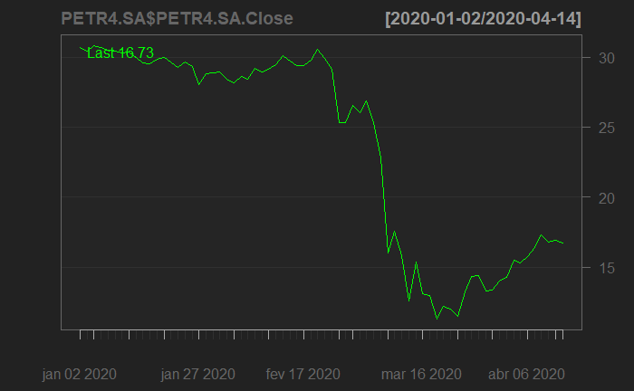

```r
quantmod::candleChart(PETR4.SA$PETR4.SA.Close)
```

3. Explore a série temporal obtida da empresa, teste outros períodos de tempo e identifique o significado dos campos trazidos da série.

```r
Data_Inicio = as.Date("2019-01-01")
Data_Fim    = as.Date("2019-04-15")
quantmod::getSymbols("PETR4.SA", src = "yahoo", from = Data_Inicio, to = Data_Fim)
```

```
PETR4.SA contains missing values. Some functions will not work if objects contain missing values in the middle of the series. Consider using na.omit(), na.approx(), na.fill(), etc to remove or replace them.
```

```
[1] "PETR4.SA"
```

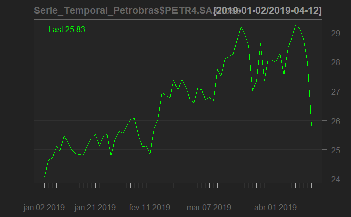

```r
Serie_Temporal_Petrobras = na.omit(PETR4.SA)
quantmod::candleChart(Serie_Temporal_Petrobras$PETR4.SA.Close)
```

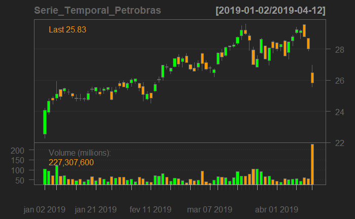

```r
candleChart(Serie_Temporal_Petrobras)
```

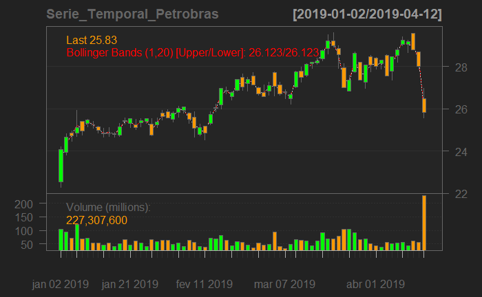

```r
addBBands(1, 20)
```